# Proportion of (temperate) reef fish at depth by ontogenetic stage at three different depths ~(surface, mixed layer, below mixed layer) in the top 100m

Steve Hawes

1 February 2015

## Overview

Proportions of stages of ontogeny of reef associated fish caught at 3 depths on the RV Investigator 2015

## Importing data and libraries

Libraries used in this code

```r
library("ggplot2") # Graphics
library("dplyr") # Arranging data
library("reshape2") # Reshaping data
library("RVAideMemoire") # Fisher multiple comparisons
library("ca")
library("vcd")
library("NCStats")
```

My data imported from my excel spreadsheet. I have printed out the first 5 rows so you get the idea. I also grouped the data by the factors of Depth and then Stage.

```r
ontogenydata <- read.csv('reef_fish.csv',skip = 2,nrows = 172) ## 172 is the first 16 sites
str(ontogenydata)
names(ontogenydata) <- tolower(names(ontogenydata))
head(ontogenydata)
```

```
## 'data.frame':    172 obs. of  35 variables:
##  $ Site             : int  1 1 1 1 1 1 1 1 1 1 ...
##  $ Depth            : int  0 0 0 0 25 25 25 75 75 75 ...
##  $ Net              : int  1 1 2 2 4 5 5 2 3 3 ...
##  $ Fixed_In         : Factor w/ 2 levels "Ethanol","Formalin": 1 2 1 2 2 1 2 2 1 2 ...
##  $ Photographed     : Factor w/ 2 levels "No","Yes": 2 2 2 2 2 2 2 2 2 2 ...
##  $ Hold_Sample      : Factor w/ 3 levels "No","Returned",..: 2 2 2 2 2 2 2 2 2 2 ...
##  $ PRE_Scaridae     : int  0 0 0 1 1 0 0 0 0 0 ...
##  $ FLE_Scaridae     : int  1 0 1 2 1 0 0 0 1 1 ...
##  $ POS_Scaridae     : int  2 0 1 0 0 0 0 3 0 1 ...
##  $ PRE_Scorpaenidae : int  0 0 0 0 1 0 3 0 0 0 ...
##  $ FLE_Scorpaenidae : int  0 0 0 1 0 0 0 0 0 1 ...
##  $ POS_Scorpaenidae : int  0 0 0 0 0 0 0 0 1 0 ...
##  $ PRE_Synodontidae : int  0 2 1 0 4 0 3 0 0 1 ...
##  $ FLE_Synodontidae : int  1 0 1 0 0 1 0 0 0 1 ...
```

[output cut: 77 more lines]

## Functions

1. getFishData()

```r
getFishData <- function(df,pre.name,fle.name,post.name){
  fish <- subset(df,select = c("site","depth", pre.name, fle.name, post.name))
  names(fish) <- c("site","depth","preflexion","flexion","postflexion")
  fishmelt <- melt(fish, id.vars = c("site","depth"),
                          measure.vars = c("preflexion","flexion","postflexion"),
                          variable.name = "stage")
  fishmelt <- group_by(fishmelt, depth, stage)
  fishmelt
}
```

```r
getProportions <- function(data){
  data$sum[data$stage == 'preflexion'] = sum(data$count[data$stage == 'preflexion'])
  data$sum[data$stage == 'flexion'] = sum(data$count[data$stage == 'flexion'])
  data$sum[data$stage == 'postflexion'] = sum(data$count[data$stage == 'postflexion'])
  data = mutate(data, prop = count / sum)
  return(data)
}
```

2. graphBuilder() uses ggplot2 to produce a line graph to visualise the differences in proportions. I might change the layout of the graph, its not entirely intuitive at the moment.

```r
graphBuilder <- function(data, title) {

    # Order the factors to print nicely on x-axis
    data$depth <- factor(data$depth, levels = c("0", "25", "75"))

    graph <- ggplot(data, aes(x = depth, y = prop, fill = stage, group = stage,
        shape = stage, colour = stage, ymax = 1, ymin = 0)) + geom_line(size = 1.5) +
        geom_point(size = 4) + ggtitle(title) + scale_y_continuous(breaks = seq(0,
        1, 0.1), limits = c(0, 1), expand = c(0, 0)) + scale_x_discrete(labels = c("0-3",
        "3-50", "50-100")) + labs(x = "Depth (m)", y = "Proportion") + scale_colour_brewer(palette = "Dark2") +
        theme(text = element_text(size = 20))
    return(graph)
}
```

3. printLineGraphForFish() is just a placer function to cut down on repeated code

```r
printLineGraphForFish <- function(countdata,title) {
  prop <- getProportions(countdata)
  graphBuilder(prop,title)
}
```

4. printMosiacGraphForFish creates mosaic images for presenting Chi-Square tests

```r
printMosaicGraphForFish <- function(countdata) {
  matrix <- acast(countdata,depth ~ stage,value.var="count")
  print(matrix)
  plot(ca(matrix))
  mosaic(matrix,shade=T,legend=T)
  assoc(matrix,shade=T,legend=T)
}
```

5. performFishersTest() performs the Fisher’s exact test to see if the proportions are significantly different by depth. It uses the reshape2 package’s acast() function to convert the data into a matrix format, with rows of Depth and columns of Stage, populated by the count variable. If the two sided fishers exact test is significant, a post-hoc of multiple comparisons using 2x2 fisher’s exact tests are used - corrected using a bonferroni approach

```r
performFishersTest <- function(countdata) {
    matrix <- acast(countdata, depth ~ stage, value.var = "count")
    ft <- fisher.test(matrix, alternative = "two.sided")
    ## print(ft)
    if (ft$p.value < 0.05) {
        mult <- fisher.multcomp(matrix, "bonferroni")
        print(mult)
    }
    return(ft)
}
```

6. performChiSqTest

```r
performChiSqTest <- function(countdata) {
    matrix <- acast(countdata, depth ~ stage, value.var = "count")
    ft <- chisq.test(matrix)
    ## print(ft)
    if (ft$p.value < 0.05) {
        mult <- chisqPostHoc(ft, control = "bonferroni")
        print(mult)
    }
    return(ft)
}
```

## Preliminary Results

### Wrasse

It uses the dplyr package to sum all the count data - the totals are needed to calculate the proportions.

```r
labrids <- getFishData(ontogenydata,"pre_labridae","fle_labridae","pos_labridae")
labrids.sum <- summarise(labrids, count = sum(value))
performChiSqTest(labrids.sum)
```

```
## Adjusted p-values used the bonferroni method.
##
##   comparison raw.p  adj.p
## 1   0 vs. 25 0e+00 0.0000
## 2   0 vs. 75 9e-04 0.0026
## 3  25 vs. 75 0e+00 0.0000
```

```
## Pearson's Chi-squared test with matrix
## X-squared = 91.5861, df = 4, p-value < 2.2e-16
```

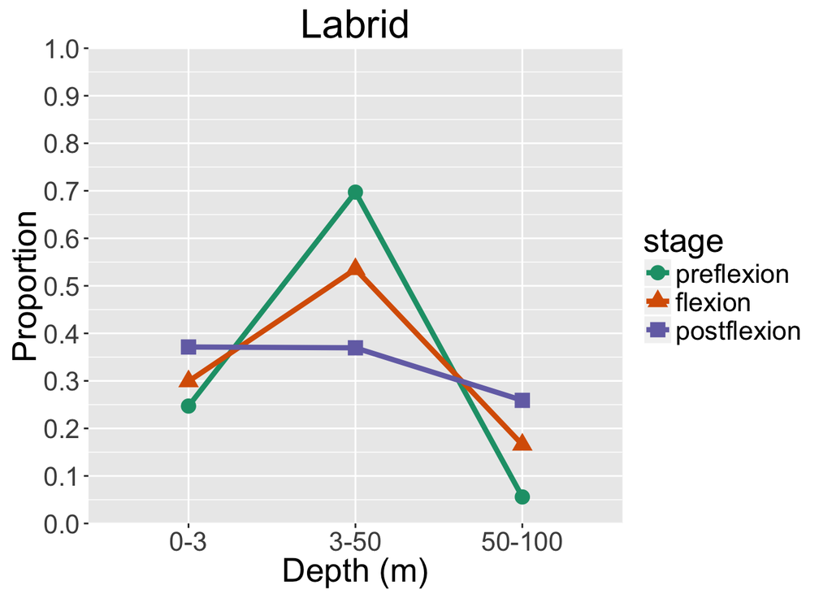

```r
printLineGraphForFish(labrids.sum,"Labrid")
```

```
##    preflexion flexion postflexion
## 0          62     166         215
## 25        175     297         214
## 75         14      92         150
```

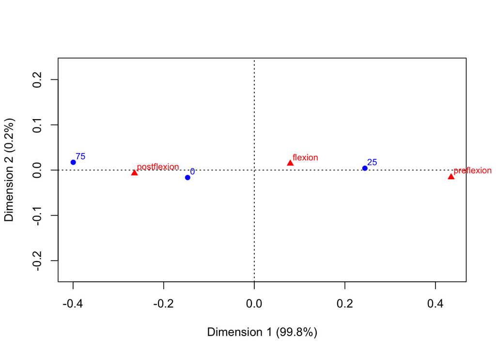

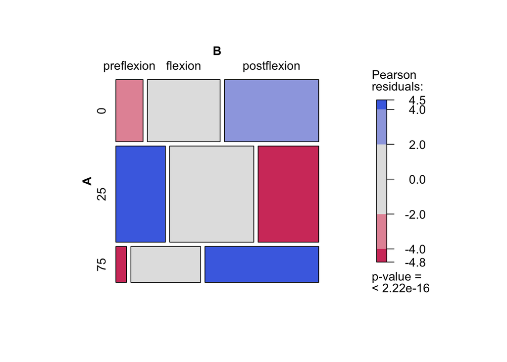

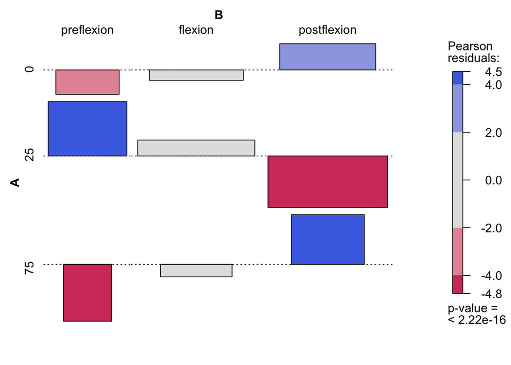

```r
printMosaicGraphForFish(labrids.sum)
```

### Parrotfish

```r
scarids <- getFishData(ontogenydata,"pre_scaridae","fle_scaridae","pos_scaridae")
scarids.sum <- summarise(scarids, count = sum(value))
performFishersTest(scarids.sum)
```

```
## Fisher's Exact Test for Count Data with matrix
## p-value = 0.2304
## alternative hypothesis: two.sided
```

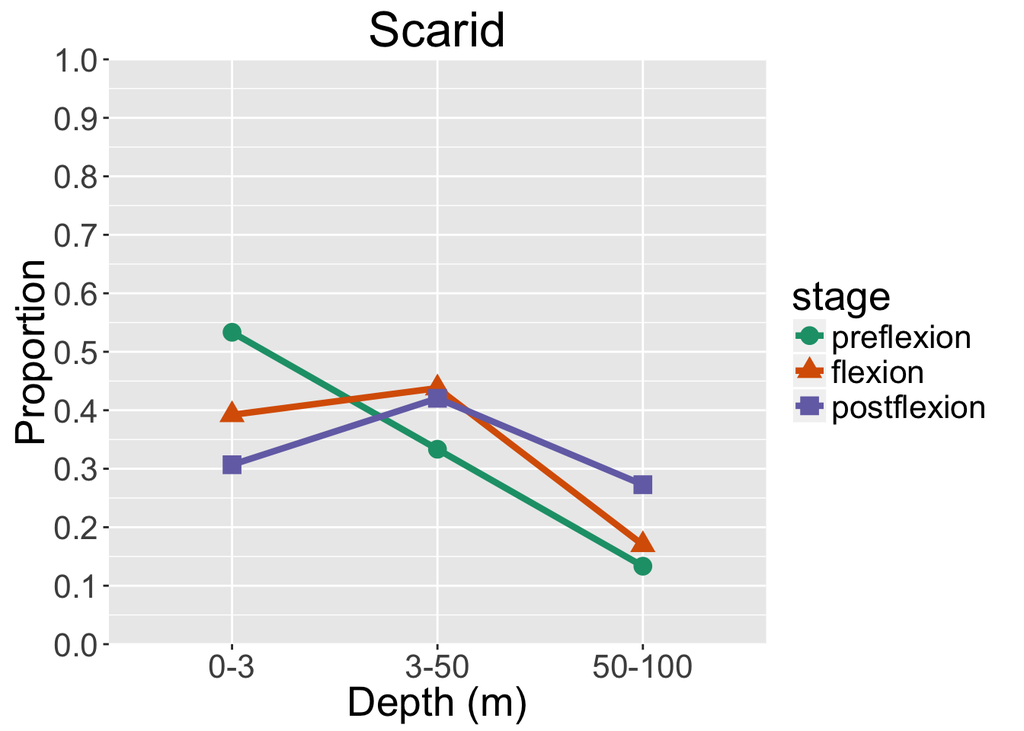

```r
printLineGraphForFish(scarids.sum,"Scarid")
```

```
##    preflexion flexion postflexion
## 0           8      60          27
## 25          5      67          37
## 75          2      26          24
```

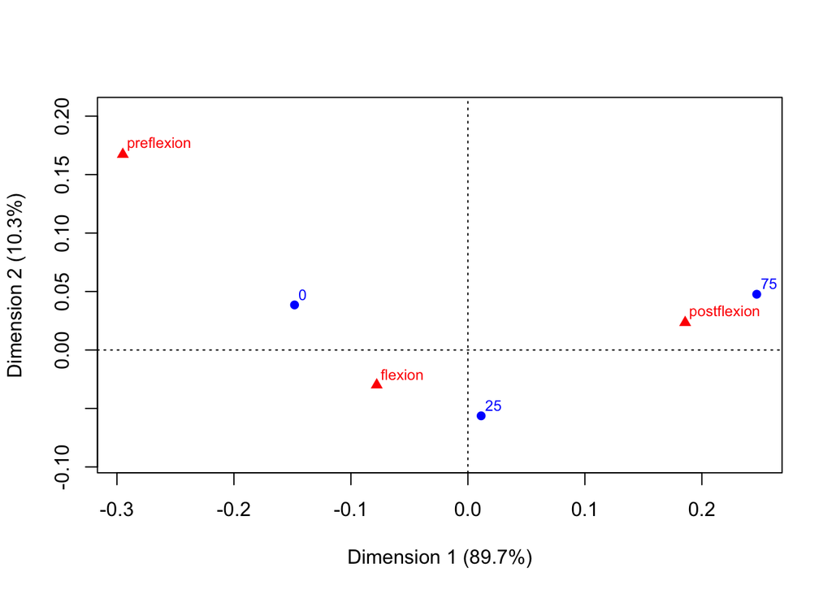

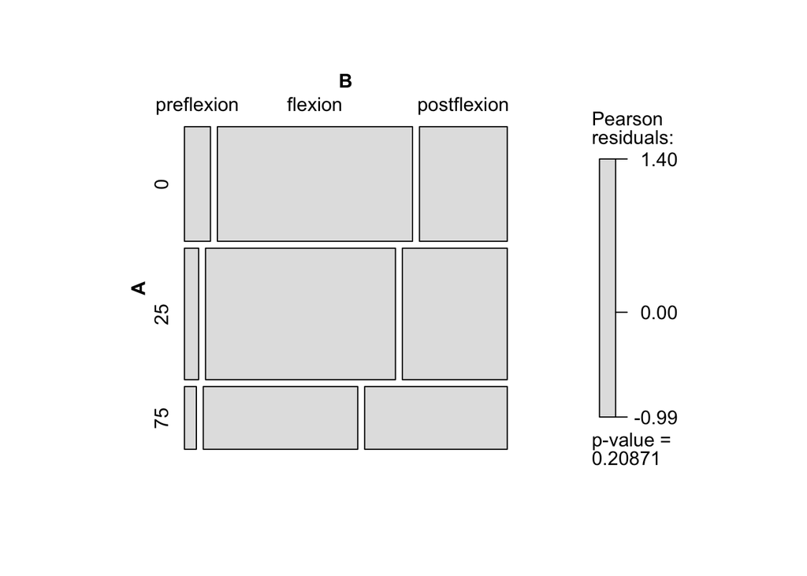

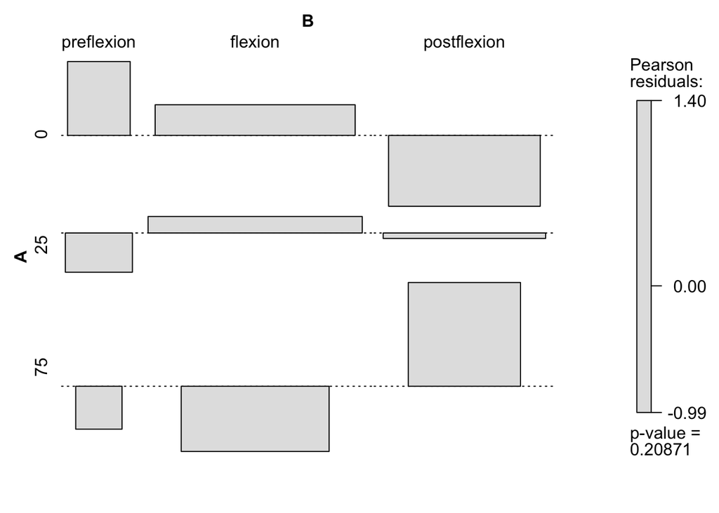

```r
printMosaicGraphForFish(scarids.sum)
```

### Flounder

```r
bothids <- getFishData(ontogenydata,"pre_bothidae","fle_bothidae","pos_bothidae")
bothids.sum <- summarise(bothids, count = sum(value))
performFishersTest(bothids.sum)
```

```
## Fisher's Exact Test for Count Data with matrix
## p-value = 0.0953
## alternative hypothesis: two.sided
```

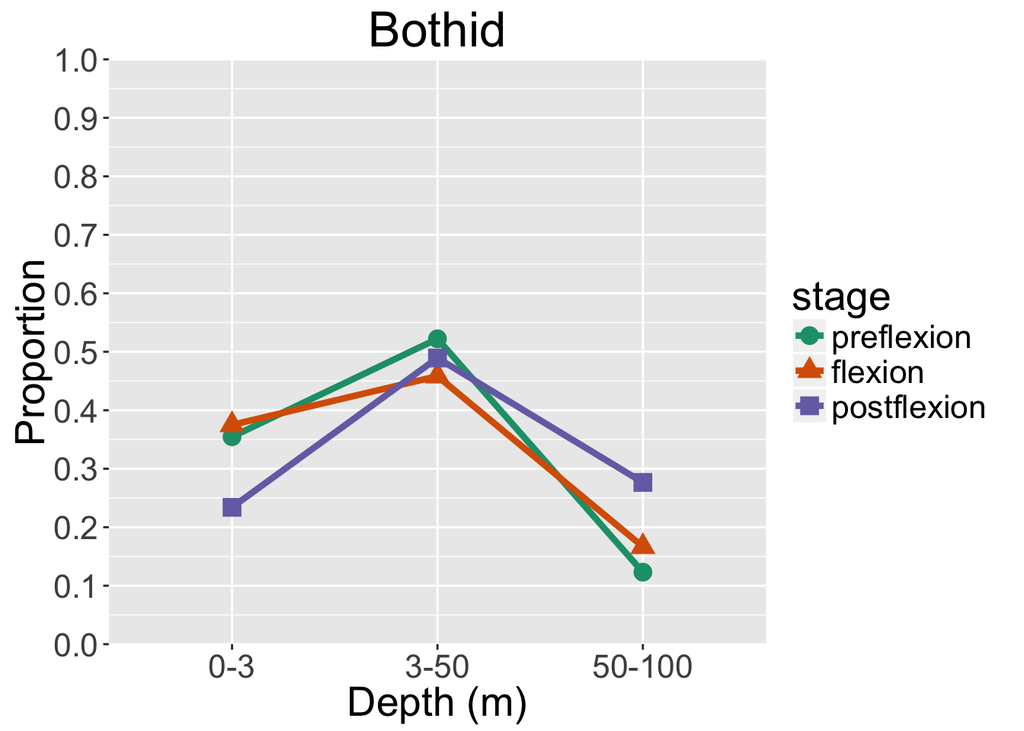

```r
printLineGraphForFish(bothids.sum,"Bothid")
```

```
##    preflexion flexion postflexion
## 0          72      27          11
## 25        106      33          23
## 75         25      12          13
```

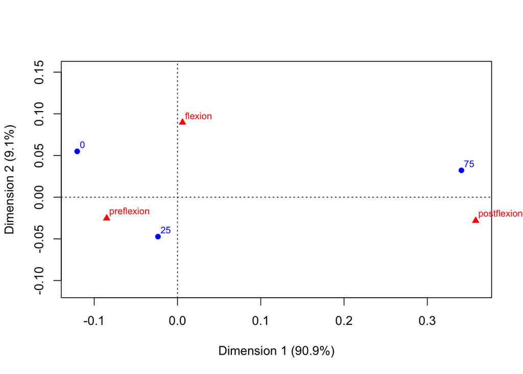

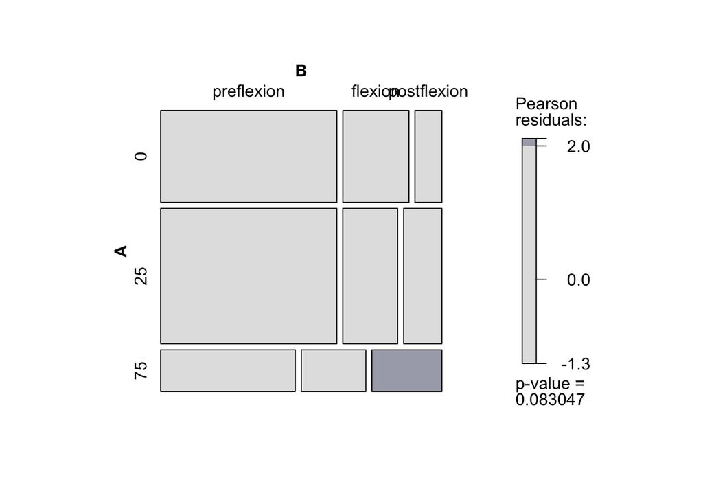

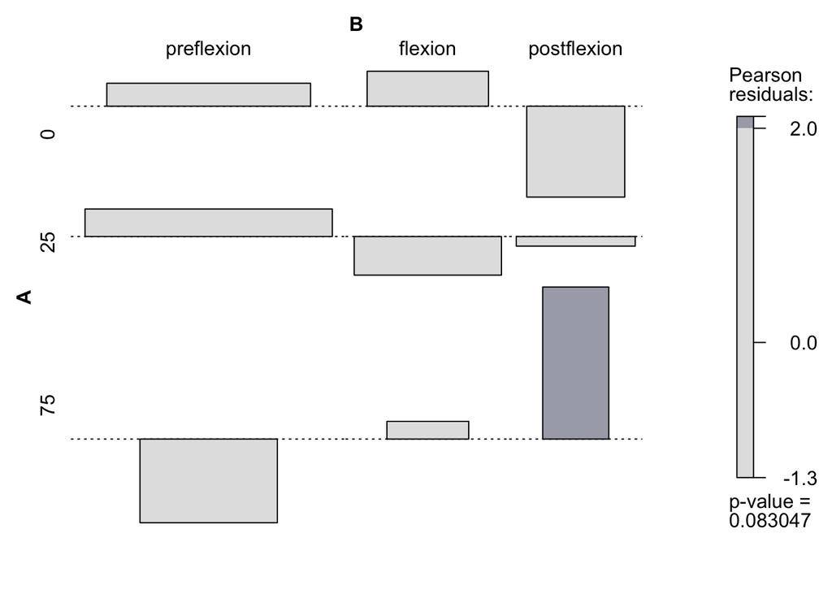

```r
printMosaicGraphForFish(bothids.sum)
```

### Scorpionfish

```r
scorpids <- getFishData(ontogenydata,"pre_scorpaenidae","fle_scorpaenidae","pos_scorpaenidae")
scorpids.sum <- summarise(scorpids, count = sum(value))
performFishersTest(scorpids.sum)
```

```
##
##         Pairwise comparisons using Fisher's exact test for count data
##
## data:  matrix
##
##       preflexion:flexion preflexion:postflexion flexion:postflexion
## 0:25                   1              1.0000000             1.00000
## 0:75                   1              0.0001715             0.01588
## 25:75                  1              0.0026951             0.14965
##
## P value adjustment method: bonferroni
```

```
## Fisher's Exact Test for Count Data with matrix
## p-value = 7.357e-05
## alternative hypothesis: two.sided
```

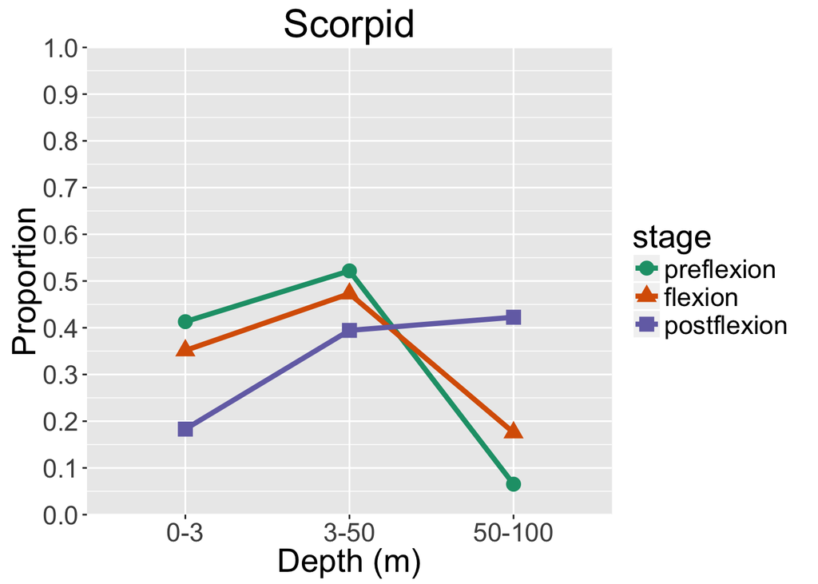

```r
printLineGraphForFish(scorpids.sum,"Scorpid")
```

```
##    preflexion flexion postflexion
## 0          19      26          13
## 25         24      35          28
## 75          3      13          30
```

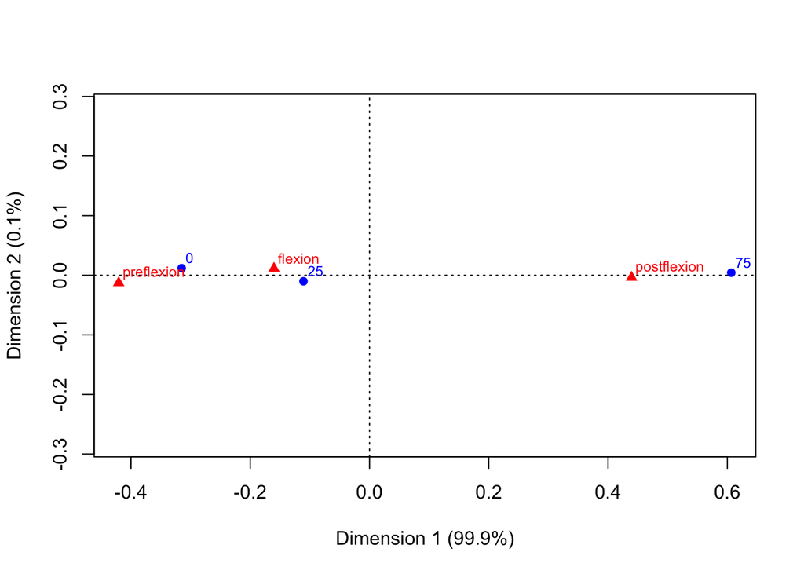

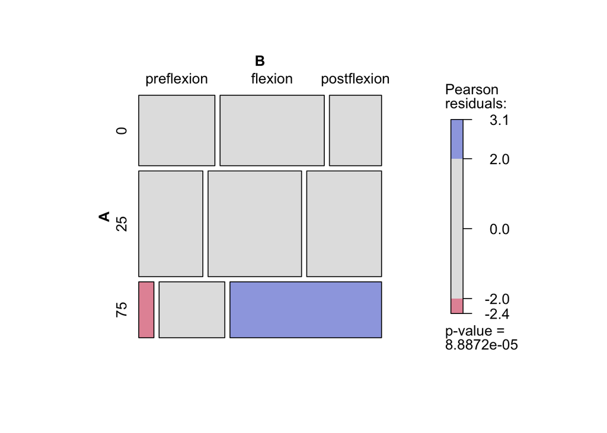

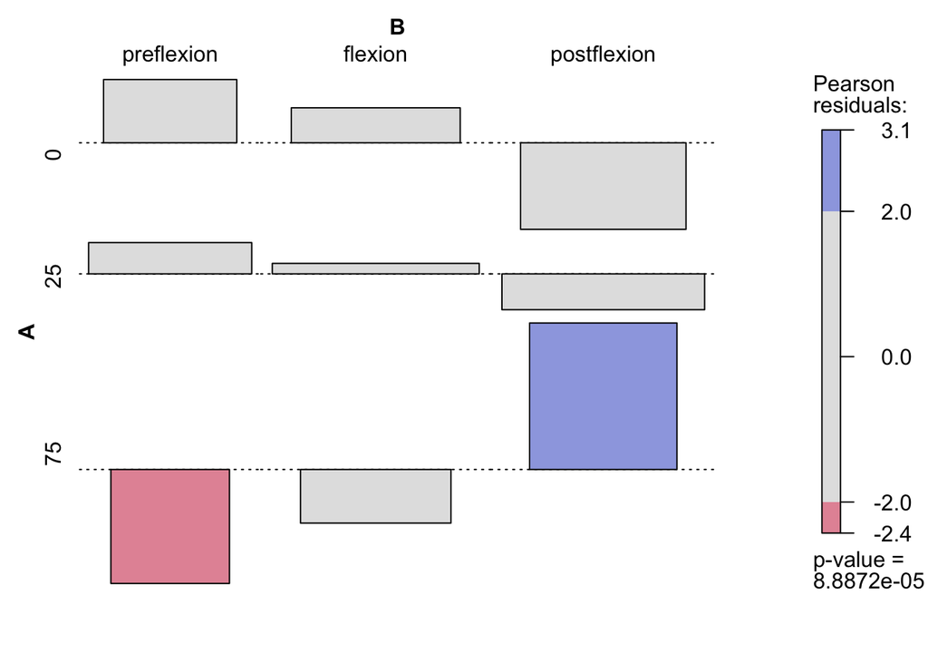

```r
printMosaicGraphForFish(scorpids.sum)
```

### Sea basses & Groupers

```r
serranids <- getFishData(ontogenydata,"pre_serranidae","fle_serranidae","pos_serranidae")
serranids.sum <- summarise(serranids, count = sum(value))
performFishersTest(serranids.sum)
```

```
##
##         Pairwise comparisons using Fisher's exact test for count data
##
## data:  matrix
##
##       preflexion:flexion preflexion:postflexion flexion:postflexion
## 0:25           1.000e+00              1.000e+00              1.0000
## 0:75           1.032e-08              5.393e-05              0.2854
## 25:75          3.376e-10              5.357e-04              1.0000
##
## P value adjustment method: bonferroni
```

```
## Fisher's Exact Test for Count Data with matrix
## p-value = 1.172e-14
## alternative hypothesis: two.sided
```

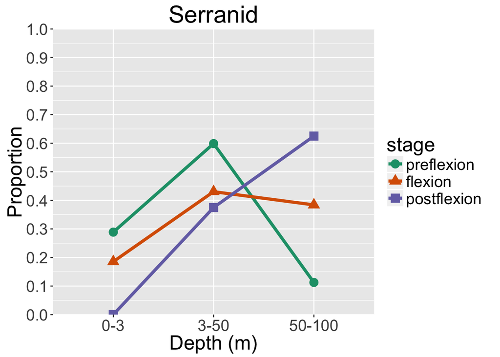

```r
printLineGraphForFish(serranids.sum,"Serranid")
```

```
##    preflexion flexion postflexion
## 0         136      28           0
## 25        282      65           6
## 75         53      58          10
```

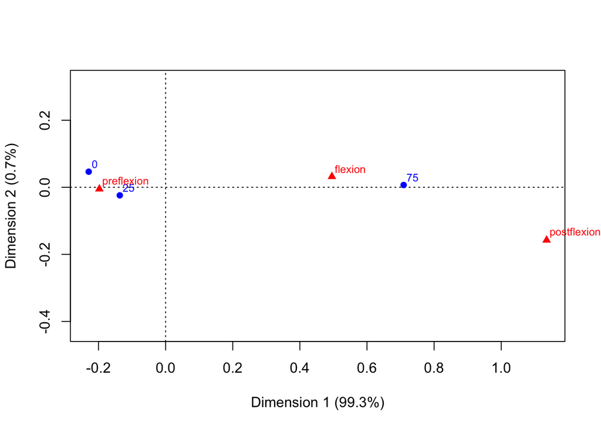

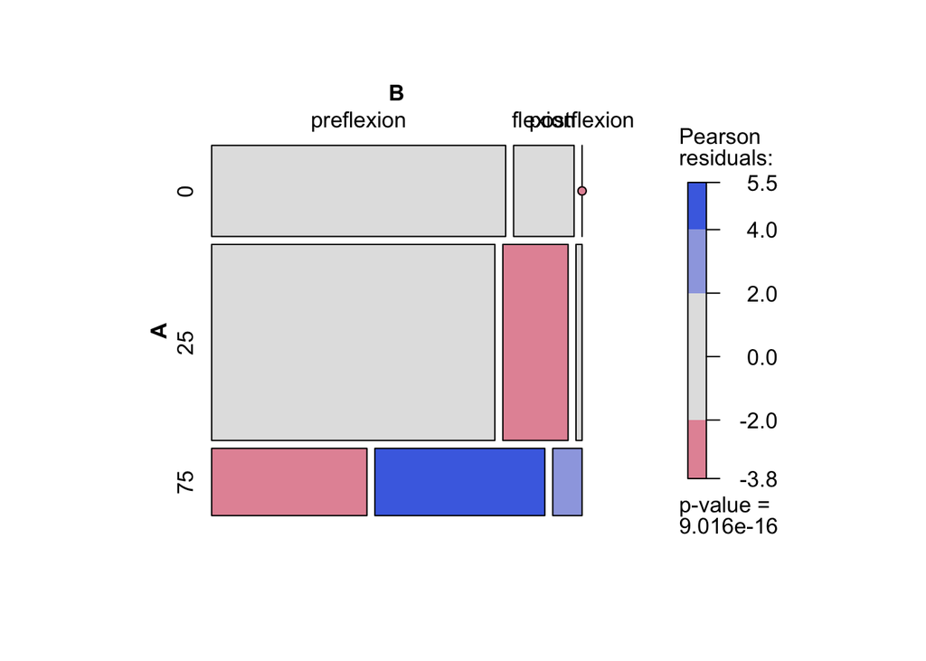

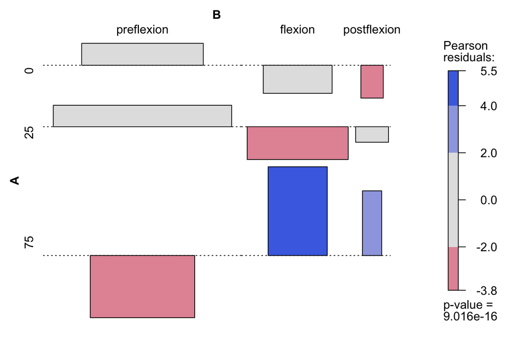

```r
printMosaicGraphForFish(serranids.sum)
```

### Lizardfish

```r
synodontids <- getFishData(ontogenydata,"pre_synodontidae","fle_synodontidae","pos_synodontidae")
synodontids.sum <- summarise(synodontids, count = sum(value))
performFishersTest(synodontids.sum)
```

```
##
##         Pairwise comparisons using Fisher's exact test for count data
##
## data:  matrix
##
##       preflexion:flexion preflexion:postflexion flexion:postflexion
## 0:25             0.10770                 0.2791                   1
## 0:75             0.02985                 1.0000                   1
## 25:75            1.00000                 1.0000                   1
##
## P value adjustment method: bonferroni
```

```
## Fisher's Exact Test for Count Data with matrix
## p-value = 0.008782
## alternative hypothesis: two.sided
```

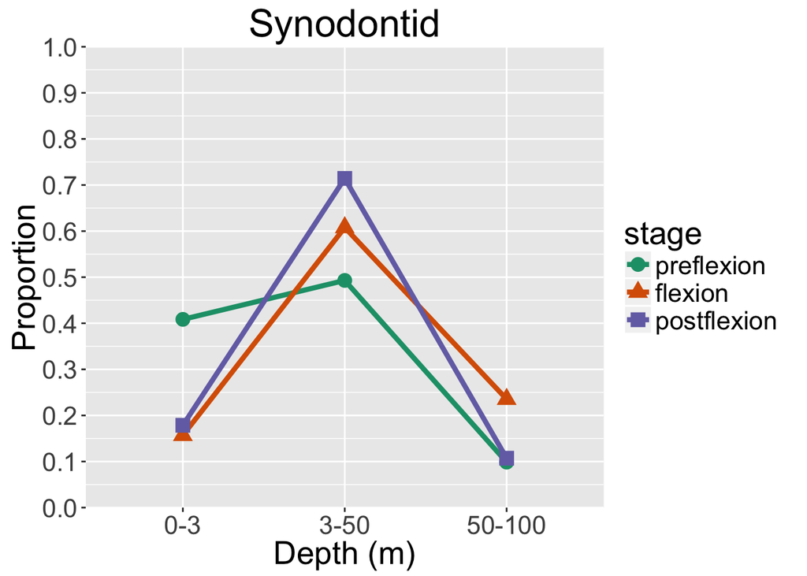

```r
printLineGraphForFish(synodontids.sum,"Synodontid")
```

```
##    preflexion flexion postflexion
## 0          29       8           5
## 25         35      31          20
## 75          7      12           3
```

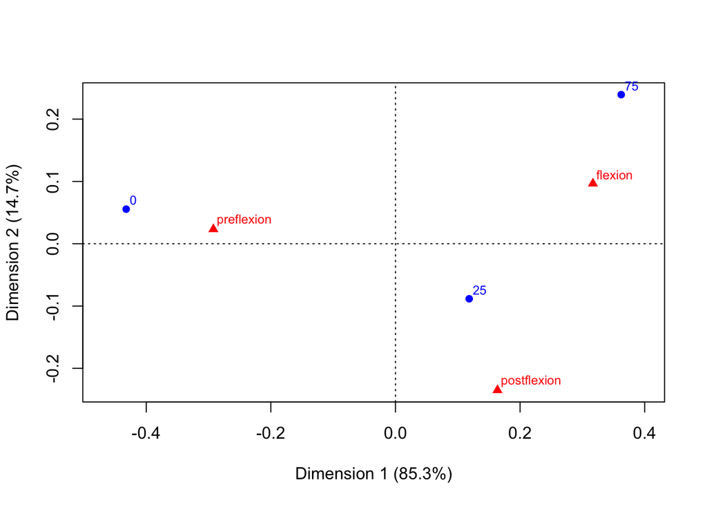

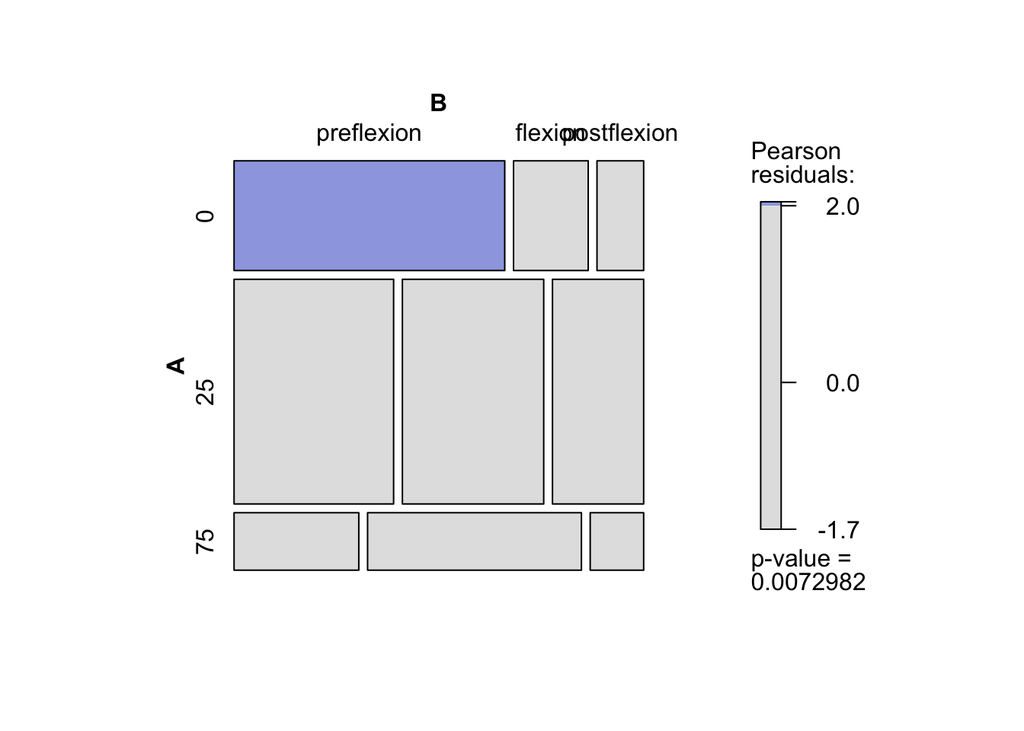

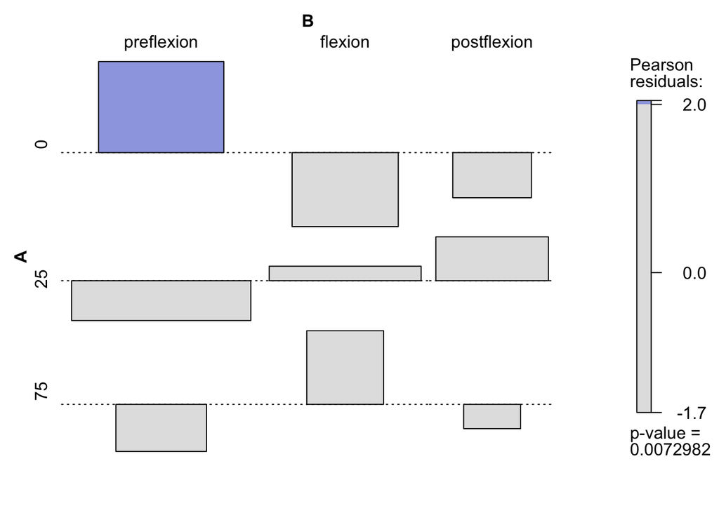

```r
printMosaicGraphForFish(synodontids.sum)
```

### Goatfish

```r
mullids <- getFishData(ontogenydata,"pre_mullidae","fle_mullidae","pos_mullidae")
mullids.sum <- summarise(mullids, count = sum(value))
performFishersTest(mullids.sum)
```

```
##
##         Pairwise comparisons using Fisher's exact test for count data
##
## data:  matrix
##
##       preflexion:flexion preflexion:postflexion flexion:postflexion
## 0:25             1.00000                0.30232             0.01922
## 0:75             0.04972                0.28368             1.00000
## 25:75            0.16528                0.01163             1.00000
##
## P value adjustment method: bonferroni
```

```
## Fisher's Exact Test for Count Data with matrix
## p-value = 0.0003857
## alternative hypothesis: two.sided
```

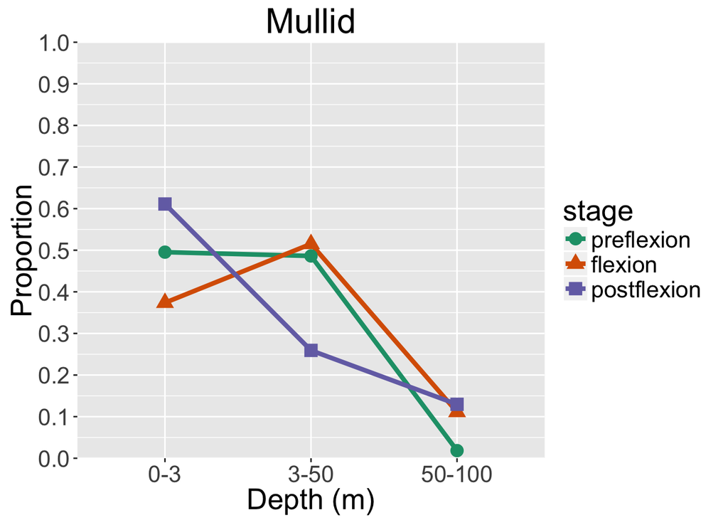

```r
printLineGraphForFish(mullids.sum,"Mullid")
```

```
##    preflexion flexion postflexion
## 0          54      37          33
## 25         53      51          14
## 75          2      11           7
```

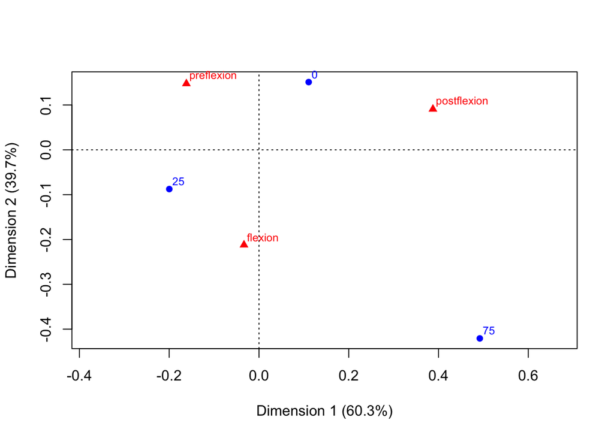

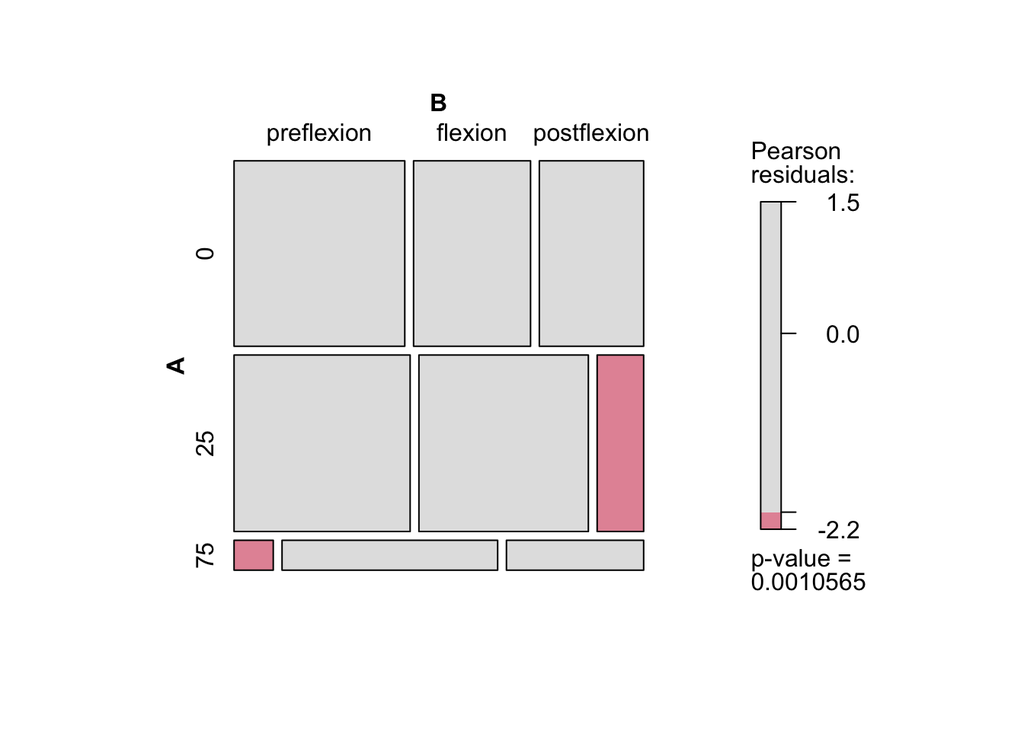

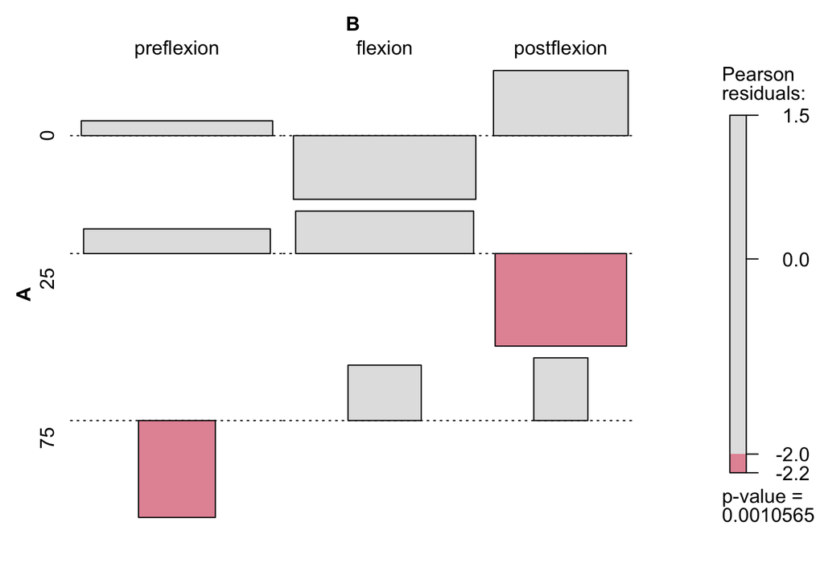

```r
printMosaicGraphForFish(mullids.sum)
```

### Damselfish

```r
pomacentrids <- getFishData(ontogenydata,"pre_pomacentridae","fle_pomacentridae","pos_pomacentridae")
pomacentrids.sum <- summarise(pomacentrids, count = sum(value))
performFishersTest(pomacentrids.sum)
```

```
##
##         Pairwise comparisons using Fisher's exact test for count data
##
## data:  matrix
##
##       preflexion:flexion preflexion:postflexion flexion:postflexion
## 0:25             0.02706                 0.1805                   1
## 0:75             0.23939                 0.3306                   1
## 25:75            1.00000                 1.0000                   1
##
## P value adjustment method: bonferroni
```

```
## Fisher's Exact Test for Count Data with matrix
## p-value = 0.002327
## alternative hypothesis: two.sided
```

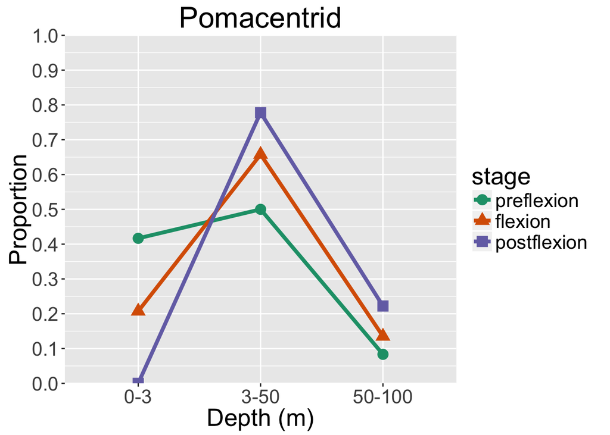

```r
printLineGraphForFish(pomacentrids.sum,"Pomacentrid")
```

```
##    preflexion flexion postflexion
## 0          40      23           0
## 25         48      73           7
## 75          8      15           2
```

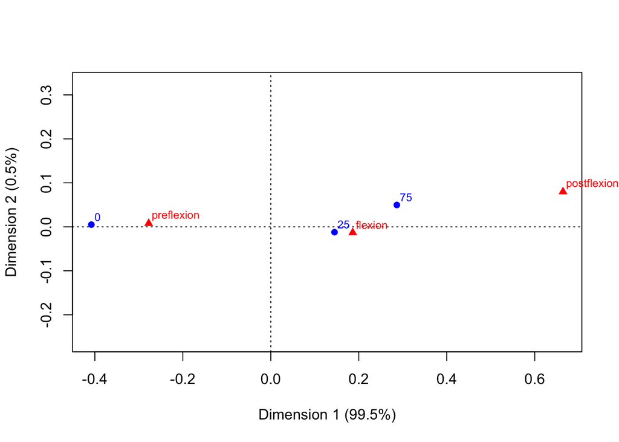

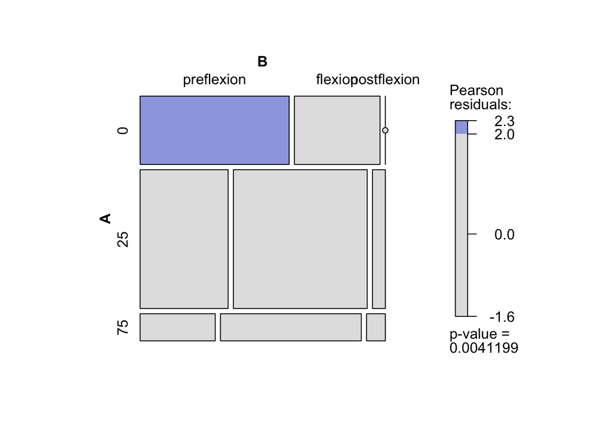

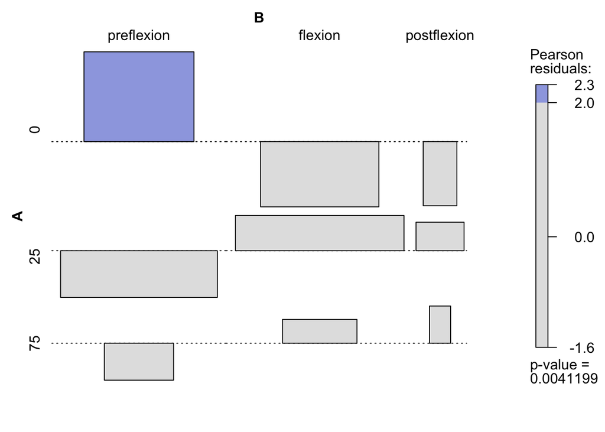

```r
printMosaicGraphForFish(pomacentrids.sum)
```